# Homework 5

John Brandt

10/27/2017

# Data Import

```r
# Input older white pine plot-level data from Hatch plots

rm(list=ls())

library(nlme)
library(ggplot2)

hatch0 <- read.fwf("Hatch.dat", skip = 9, header = F,
                   row.names = NULL, as.is = TRUE,  strip.white=T,
                   widths = c(4, 7, 8, 8, 8, 8, 8),
                   col.names = c("plot", "siteindex", "age", "NTA",
                                 "qmd", "BAA", "DHT") )

cat("\n",nrow(hatch0)," records were read.\n",sep="") #
```

```
##
## 173 records were read.
```

```r
# omit rows of dashes and convert plot to factor variable,
# and convert the rest to numeric

hatch <- hatch0[-which(hatch0$plot == "---"),]

hatch$plot <- as.factor(hatch$plot)
hatch$siteindex <- as.numeric(hatch$siteindex)
hatch$age <- as.numeric(hatch$age)
hatch$NTA <- as.numeric(hatch$NTA)
hatch$qmd <- as.numeric(hatch$qmd)
hatch$BAA <- as.numeric(hatch$BAA)
hatch$DHT <- as.numeric(hatch$DHT)
attach(hatch)
```

# Preliminary plotting of IV/DV relationships

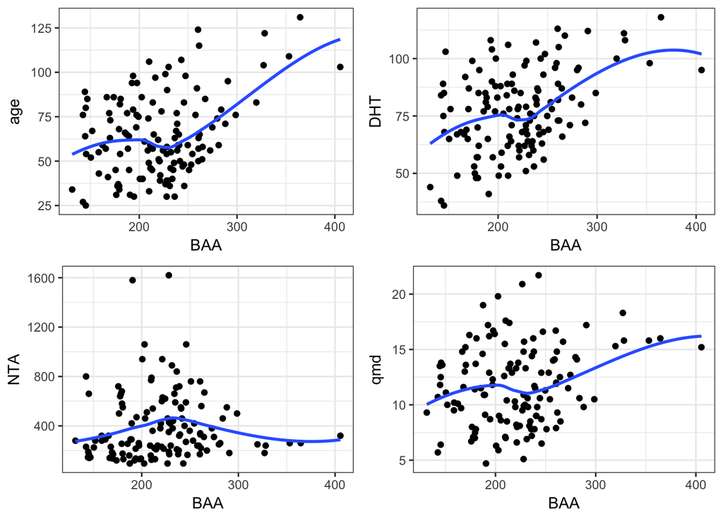

```r
BAA_age <- ggplot(data=hatch, aes(BAA, age))+
  geom_point()+
  geom_smooth(se=FALSE)+
  theme_bw()

BAA_NTA <- ggplot(data=hatch, aes(BAA, NTA))+
  geom_point()+
  geom_smooth(se=FALSE)+
  theme_bw()

BAA_DHT <- ggplot(data=hatch, aes(BAA, DHT))+
  geom_point()+
  geom_smooth(se=FALSE)+
  theme_bw()

BAA_qmd <- ggplot(data=hatch, aes(BAA, qmd))+
  geom_point()+
  geom_smooth(se=FALSE)+
  theme_bw()

multiplot(BAA_age, BAA_NTA, BAA_DHT, BAA_qmd, cols=2)
```

# Trellis plot

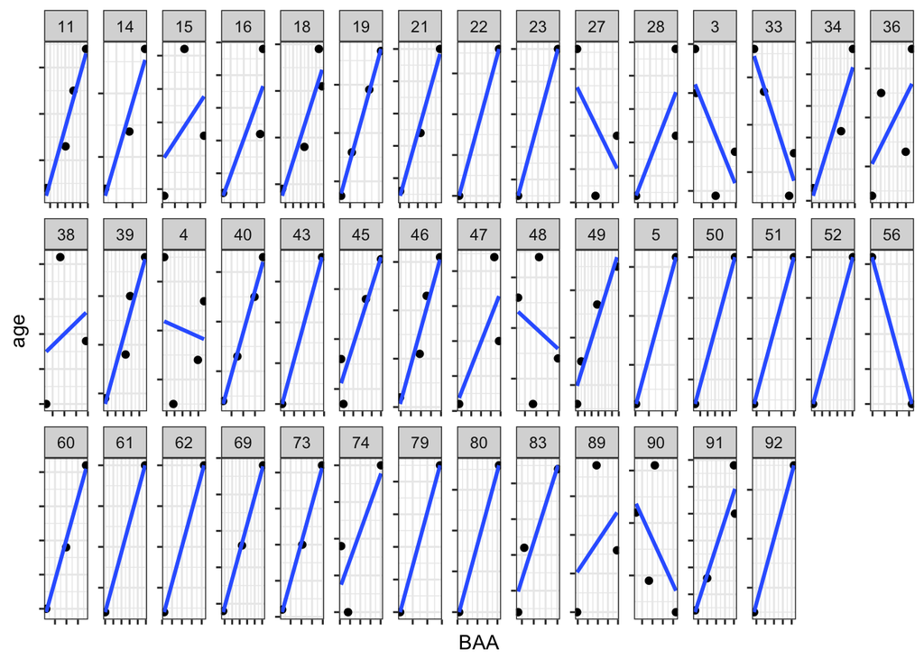

```r
BAA_agetrellis <- ggplot(data=hatch, aes(BAA, age))+
  geom_point()+
  geom_smooth(se=FALSE, method="lm")+
  theme_bw()+
    facet_wrap(~plot, ncol=15, scales="free")+
    theme(axis.text.y=element_blank(),
          axis.text.x=element_blank())

print(BAA_agetrellis)
```

# Transformations

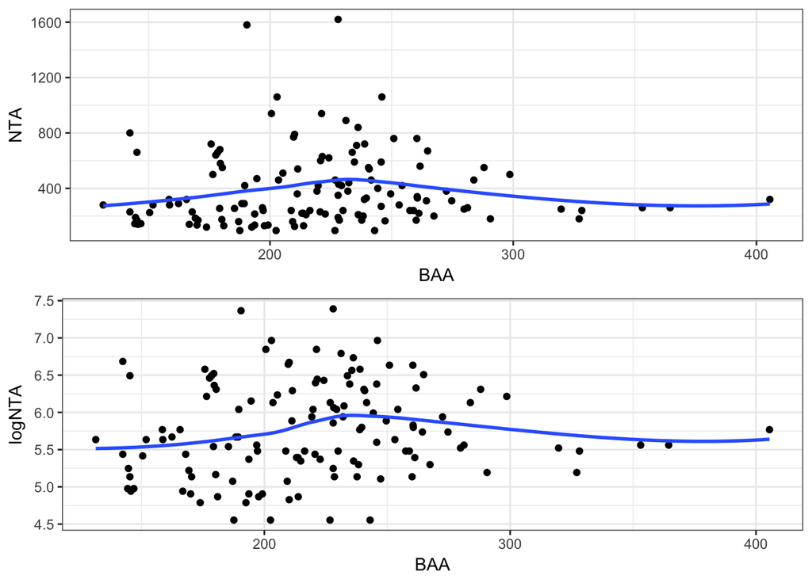

```r
hatch$logNTA <- log(NTA)
logNTA <- log(NTA)

BAA_logNTA <- ggplot(data=hatch, aes(BAA, logNTA))+
  geom_point()+
  geom_smooth(se=FALSE)+
  theme_bw()

multiplot(BAA_NTA, BAA_logNTA)
```

# GLS Model

```r
cor1 <- gls(BAA ~ age, corr=corCAR1(form = ~ age | plot))
cor2 <- gls(BAA ~ age + logNTA, corr=corCAR1(form = ~ age | plot))
cor3 <- gls(BAA ~ age + logNTA + qmd, corr=corCAR1(form = ~ age | plot))
cor4 <- gls(BAA ~ age + logNTA + qmd + DHT, corr=corCAR1(form = ~ age | plot))
cor5 <- gls(BAA ~ age + siteindex + logNTA + qmd + DHT, corr=corCAR1(form = ~ age | plot),
            data=hatch)
```

## AIC

Cor 3 and Cor4 have very similar AIC scores, so let’s look and see whether DHT improves the model.

```r
AIC(cor1, cor2, cor3, cor4, cor5)
```

```
##      df      AIC
## cor1  4 1230.807
## cor2  5 1178.128
## cor3  6 1101.492
## cor4  7 1100.703
## cor5  8 1093.979
```

```r
summary(cor5)
```

```
## Generalized least squares fit by REML
##   Model: BAA ~ age + siteindex + logNTA + qmd + DHT
##   Data: hatch
##        AIC      BIC    logLik
##   1093.979 1116.605 -538.9893
##
## Correlation Structure: Continuous AR(1)
##  Formula: ~age | plot
##  Parameter estimate(s):
##       Phi
## 0.9775114
##
## Coefficients:
##                 Value Std.Error    t-value p-value
## (Intercept) -967.0475  71.36003 -13.551668  0.0000
## age            0.6577   0.28448   2.312067  0.0224
## siteindex      1.7039   0.59194   2.878442  0.0047
## logNTA       132.7568   9.33265  14.224977  0.0000
## qmd           21.2479   2.34854   9.047255  0.0000
## DHT            0.2141   0.23198   0.923033  0.3578
##
##  Correlation:
##           (Intr) age    sitndx logNTA qmd
## age        0.046
## siteindex -0.249  0.537
## logNTA    -0.855 -0.293 -0.275
## qmd       -0.624 -0.587 -0.355  0.782
## DHT        0.053 -0.608 -0.413  0.112 -0.007
##
## Standardized residuals:
##          Min           Q1          Med           Q3          Max
## -2.475213951 -0.487014861 -0.004767837  0.576074501  3.611333584
##
## Residual standard error: 22.10902
## Degrees of freedom: 131 total; 125 residual
```

## VIF

The VIF scores indicate that there is highly colinear data.

```r
(car::vif(cor5))
```

```
##       age siteindex    logNTA       qmd       DHT
##  7.878714  1.468252  5.797251 11.825073  4.753782
```

DHT, NTA, age, and QMD are all highly correlated.

## Multicolinearity

```r
round(cor(hatch[,2:7]),2)
```

```
##           siteindex   age   NTA   qmd  BAA   DHT
## siteindex      1.00 -0.21  0.00  0.04 0.31  0.17
## age           -0.21  1.00 -0.64  0.81 0.37  0.88
## NTA            0.00 -0.64  1.00 -0.83 0.03 -0.68
## qmd            0.04  0.81 -0.83  1.00 0.23  0.83
## BAA            0.31  0.37  0.03  0.23 1.00  0.42
## DHT            0.17  0.88 -0.68  0.83 0.42  1.00
```

### Removing multicolinear variables

Qualitatively, we would choose to remove QMD first, because it is a function of both NTA and BAA. But we’ll test out all the options before making a decision.

Rebuilding model 5 without DHT improves the AIC

```r
gls_no_DHT <- gls(BAA ~ age + siteindex + logNTA + qmd, corr=corCAR1(form = ~ age | plot),
                  data=hatch)
gls_no_NTA <- gls(BAA ~ age + siteindex + qmd + DHT, corr=corCAR1(form = ~ age | plot),
                  data=hatch)
gls_no_age <- gls(BAA ~ siteindex + logNTA + qmd + DHT, corr=corCAR1(form = ~ age | plot),
                  data=hatch)
gls_no_QMD <- gls(BAA ~ age + siteindex + logNTA + DHT, corr=corCAR1(form = ~ age | plot),
                  data=hatch)

AIC(gls_no_DHT, gls_no_NTA, gls_no_age, gls_no_QMD, cor5)
```

```
##            df      AIC
## gls_no_DHT  7 1091.734
## gls_no_NTA  7 1217.617
## gls_no_age  7 1096.547
## gls_no_QMD  7 1157.569
## cor5        8 1093.979
```

I choose to remove both DHT and QMD for the following reasons: DHT has not been significant in any of the models built thus far, and QMD has a very large VIF score, indicating that it’s highly multicolinear with other predictors.

### VIF

```r
#VIF scores with only DHT removed
(round(car::vif(gls_no_DHT), 2))
```

```
##       age siteindex    logNTA       qmd
##      4.99      1.21      5.68     11.80
```

## Final gls model

The residuals look okay. It seems that the GLS model is not properly accounting for the varying distribution of residuals between plots, so let’s try building a mixed-effect LME

```r
gls_final <-  gls(BAA ~ age + siteindex + logNTA, corr=corCAR1(form = ~ age | plot),
                  data=hatch)
summary(gls_final)
```

```
## Generalized least squares fit by REML
##   Model: BAA ~ age + siteindex + logNTA
##   Data: hatch
##        AIC      BIC    logLik
##   1155.497 1172.562 -571.7485
##
## Correlation Structure: Continuous AR(1)
##  Formula: ~age | plot
##  Parameter estimate(s):
##       Phi
## 0.9834442
##
## Coefficients:
##                 Value Std.Error   t-value p-value
## (Intercept) -582.3765  76.08954 -7.653832       0
## age            2.3869   0.19872 12.011520       0
## siteindex      3.8708   0.70325  5.504262       0
## logNTA        67.3931   7.65080  8.808635       0
##
##  Correlation:
##           (Intr) age    sitndx
## age       -0.688
## siteindex -0.704  0.152
## logNTA    -0.763  0.740  0.095
##
## Standardized residuals:
##         Min          Q1         Med          Q3         Max
## -1.97628906 -0.75643865 -0.03232215  0.73593372  2.93678049
##
## Residual standard error: 30.66846
## Degrees of freedom: 131 total; 127 residual
```

```r
#VIF scores with both DHT and QMD removed
(round(car::vif(gls_final), 2))
```

```
##       age siteindex    logNTA
##      2.25      1.02      2.21
```

## GLS plots

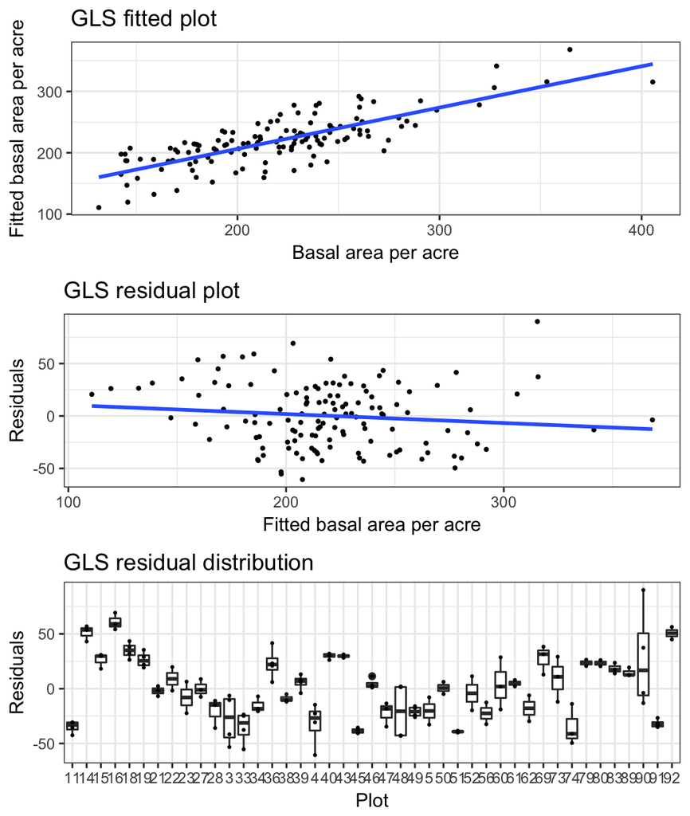

```r
hatch$resid_gls <- resid(gls_final)
hatch$fitted_gls <- fitted(gls_final)
gls_yhat <- ggplot(data=hatch, aes(x=BAA, y=fitted_gls))+
  geom_point(size=0.7)+
  geom_smooth(method=lm, se=FALSE)+
  theme_bw()+
  ggtitle("GLS fitted plot")+
  xlab("Basal area per acre")+
  ylab("Fitted basal area per acre")

gls_resid <- ggplot(data=hatch, aes(x=fitted_gls, y=resid_gls))+
  geom_point(size=0.7)+
  geom_smooth(method=lm, se=FALSE)+
  theme_bw()+
  ggtitle("GLS residual plot")+
  xlab("Fitted basal area per acre")+
  ylab("Residuals")

gls_boxplot <- ggplot(data=hatch, aes(x=plot, y=resid_gls))+
  geom_boxplot()+
  geom_point(size=0.4)+
  theme_bw()+
  ggtitle("GLS residual distribution")+
  ylab("Residuals")+
  xlab("Plot")

multiplot(gls_yhat, gls_resid, gls_boxplot)
```

# LME Model

```r
#model with all covariates
lme1 <- lme(BAA ~ age + siteindex + logNTA + qmd + DHT, random = ~ 1 + age | plot,
            data=hatch)

#model with same covariates as the GLS model
lme2 <- lme(BAA ~ age + siteindex + logNTA, random = ~ 1 + age | plot, data=hatch)
```

## AIC

```r
AIC(lme1, lme2)
```

```
##      df      AIC
## lme1 10 1072.158
## lme2  8 1177.159
```

The AIC of the model with all the covariates performs better than the model with the GLS covariates. Let’s see why.

## Summary

```r
summary(lme1)
```

```
## Linear mixed-effects model fit by REML
##  Data: hatch
##        AIC      BIC    logLik
##   1072.158 1100.442 -526.0792
##
## Random effects:
##  Formula: ~1 + age | plot
##  Structure: General positive-definite, Log-Cholesky parametrization
##             StdDev    Corr
## (Intercept) 63.856737 (Intr)
## age          1.129094 -0.991
## Residual     7.564421
##
## Fixed effects: BAA ~ age + siteindex + logNTA + qmd + DHT
##                  Value Std.Error DF    t-value p-value
## (Intercept) -1247.7488  59.10755 84 -21.109806  0.0000
## age             0.7866   0.27689 84   2.840823  0.0056
## siteindex       1.1900   0.39648 41   3.001325  0.0046
## logNTA        174.8648   7.67539 84  22.782535  0.0000
## qmd            30.7850   1.73365 84  17.757299  0.0000
## DHT            -0.2014   0.19159 84  -1.051123  0.2962
##  Correlation:
##           (Intr) age    sitndx logNTA qmd
## age       -0.247
## siteindex -0.214  0.511
## logNTA    -0.897 -0.047 -0.198
## qmd       -0.731 -0.237 -0.299  0.858
## DHT        0.317 -0.580 -0.549 -0.132 -0.162
##
## Standardized Within-Group Residuals:
##         Min          Q1         Med          Q3         Max
## -2.37108910 -0.36840341 -0.02112503  0.36903335  4.57793898
##
## Number of Observations: 131
## Number of Groups: 43
```

## Removing insignificant variables

Remove DHT because it is not significant.

```r
lme3 <- lme(BAA ~ age + siteindex + logNTA + qmd, random = ~ 1 + age | plot, data=hatch)
```

## Removing multicolinear variables

The AIC does just as well when removing the insignificant DHT, but the VIF still indicates that QMD is highly covariate (VIF > 5). Because of this covariance, we also remove it from the model and result in the same model structure as the GLS.

## AIC and VIF

```r
AIC(lme3)
```

```
## [1] 1069.7
```

```r
round(car::vif(lme3), 2)
```

```
##       age siteindex    logNTA       qmd
##      1.49      1.32      4.61      5.91
```

# Comparison between GLS and LME

The LME random-effects model better accounted for the longitudinal data. This can be seen by the more equal residual variance in the residual by plot boxplots, and in the more evenly distributed residuals in the residual vs. fitted plot. The residual vs. fitted plot also shows that the LME model better fits the data because the residuals are closer to zero.

The AIC for the GLS was 1155, while the AIC for the LME was 1177. This is because the LME introduces more degrees of freedom. The AIC is not a foolproof test of best model in this case, as the lowest AIC model clearly has heteroskedasticity between plots.

```r
require(ggalt)
```

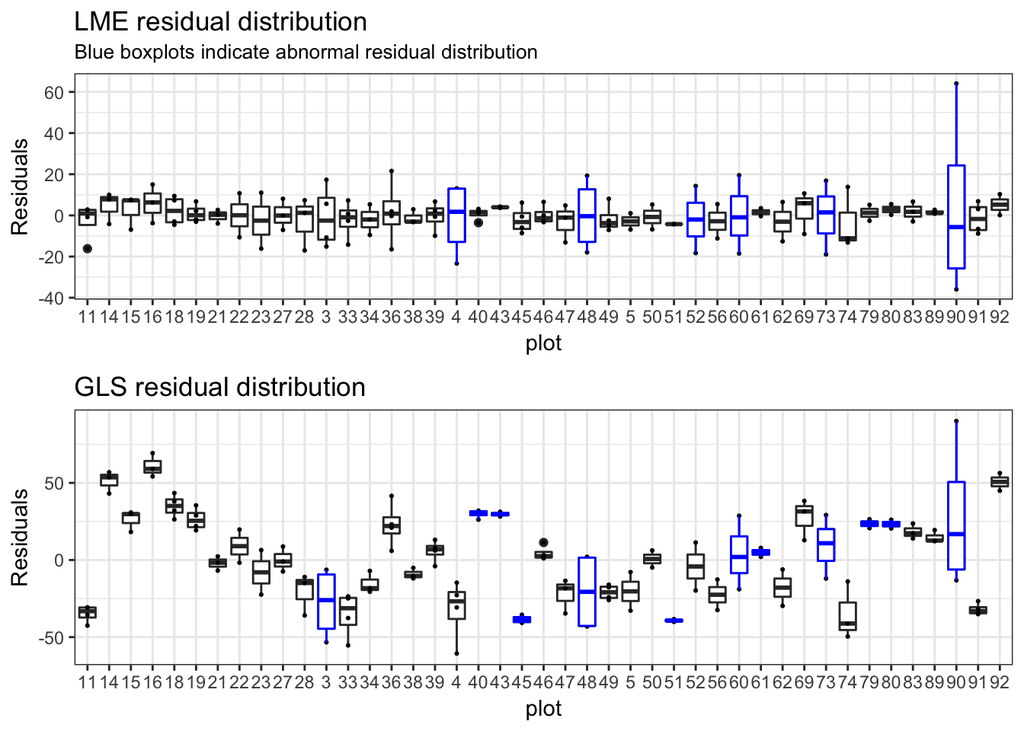

```r
hatch$lmeresid <- resid(lme2)
hatch$glsresid <- resid(gls_final)

lme2bp <- ggplot(data=hatch, aes(x=plot, y=lmeresid))+
  geom_boxplot()+
  geom_point(size=0.4)+
  theme_bw()+
  labs(title="LME residual distribution", subtitle="Blue boxplots indicate abnormal residual distribution")+
  ylab("Residuals")+
  geom_boxplot(data=subset(hatch, plot %in% c("90", "4", "48", "52", "60", "73")),
               color="blue")

cor4bp <- ggplot(data=hatch, aes(x=plot, y=glsresid))+
  geom_boxplot()+
  geom_point(size=0.4)+
  theme_bw()+
  ggtitle("GLS residual distribution")+
  ylab("Residuals")+
  geom_boxplot(data=subset(hatch, plot %in% c("3", "48", "51", "40", "43", "60", "73"
                                              , "90", "45", "61", "79", "80")),
               color="blue")

multiplot(lme2bp, cor4bp)
```

```r
AIC(lme2, gls_final)
```

```
##           df      AIC
## lme2       8 1177.159
## gls_final  6 1155.497
```

```r
gls_resid <- ggplot(data=hatch, aes(x=fitted(gls_final), y=resid(gls_final)))+
  geom_point(size=0.7)+
  geom_smooth(method=lm, se=FALSE)+
  theme_bw()+
  ggtitle("GLS residual plot")+
  xlab("Fitted")+
  ylab("Residuals")

hatch$lmefitted <- fitted(lme2)
lme_resid <- ggplot(data=hatch, aes(x=lmefitted, y=lmeresid))+
  geom_point(size=0.7)+
  geom_smooth(method=lm, se=FALSE)+
  theme_bw()+
  ggtitle("LME residual plot")+
  xlab("Fitted")+
  ylab("Residuals")+
  geom_encircle(data=subset(hatch, lmeresid>40), s_shape=0.05, expand= 0, color="blue")+
  geom_encircle(data=subset(hatch, lmefitted > 360), s_shape=0.05,
                expand= 0.08, color="blue")+
  geom_point(data=subset(hatch, lmeresid>40), color="blue", size=0.7)+
  geom_point(data=subset(hatch, lmefitted > 360), color="blue", size=0.7)+
  annotate("text", x= 295, y= 59, label="Plot 90", color="blue")+
  annotate("text", x=315, y= -33, label="Plot 90", color="blue")
```

Our final model is as follows:

BAA ~ age + siteindex + logNTA, random = ~ 1 + age | plot

AIC: 1177 logLik: -580 Age: 2.11, error = 0.2 Siteindex: 3.30, error = 0.62 log NTA = 55.32, error = 7.00

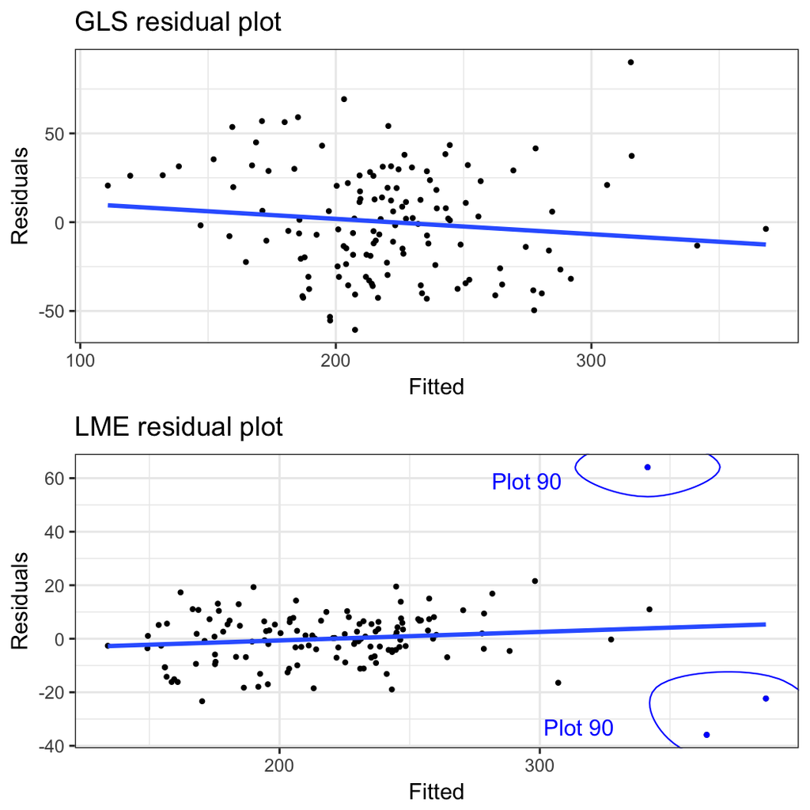

```r
multiplot(gls_resid, lme_resid)
```